# ggplot2

Ryan Yancey

1/8/2021

# Introduction

- ggplot2 implements *Grammar of Graphics* by Leland Wilkinson
- It is a “third” graphics system for R (alongside **base** and **lattice**)
- Use `install.packages("ggplot2")` to install
- [Better documentation](http://ggplot2.org)

### What is ggplot2?

- Since it’s based on Wilkinson’s book, its grammar represents abstractions of ideas/objects
- Essentially, “verbs”, “nouns”, “adjectives” for graphics
- “Shorten distance form mind to page”

### Grammar of Graphics

> “In brief, the grammar tells us that a statistical graphic is a **mapping** from data to aesthetic attributes (colour, shape, size) of **geometric** objects (points, lines, bars). The plot may also contain statistical transformations of the data and is drawn on a specific coordinate system” – *ggplot2* book

### The Basics: `qplot()`

- Similar to `plot()` in the base graphics system.
- Looks for data in data frame, or in the parent environment. But it is generally smarter to use a data frame so that when you’re reading the code it’s easier to see where the data came from.
- It is really important to organize the data frame **before** plotting.
- **Plots are made up of *aesthetics* (size, shape, color) and *geoms* (points, lines).**
- Subsetting the data is shown *via* factors; They should be labeled with **informative** labels (‘male’ and ‘female’ rather than 1 and 2) and can be used to **annotate** the plot with various colors and levels.
- `qplot()` hides what happens underneath in `ggplot` but it is fine for many applications.
- `ggplot()` is the core function that may be used in many circumstances that `qplot()` cannot do.

# Example Dataset

```r
library(ggplot2)
str(mpg)

## Need to add factors since they are not loaded by default
mpg <- transform(mpg,
                 manufacturer = factor(manufacturer),
                 model = factor(model),
                 trans = factor(trans),
                 drv = factor(drv),
                 fl = factor(fl),
                 class = factor(class))

str(mpg)
```

[output not shown]

### ggplot2 “Hello world!” plot

Here is a basic `qplot()` call for plotting highway mpg versus engine displacement.

```r
qplot(displ, hwy, data = mpg)
```

[output not shown]

Now let’s modify **aesthetics** based on factors… by drive type to be exact.

```r
qplot(displ, hwy, data = mpg, color = drv)
```

[output not shown]

### Adding a geom

We can also add a summary geom (smoother to show overall trend).

```r
## We need to specify both smooth *AND* point to get normal plots + line
qplot(displ, hwy, data = mpg, geom = c("smooth", "point"))
```

[output not shown]

### Histograms

Calling `qplot()` with only one variable makes a histogram (calling `fill` separates each bin into the drive type as well).

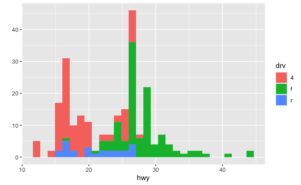

### Facets

Another way to subset data is to use `facets` function.

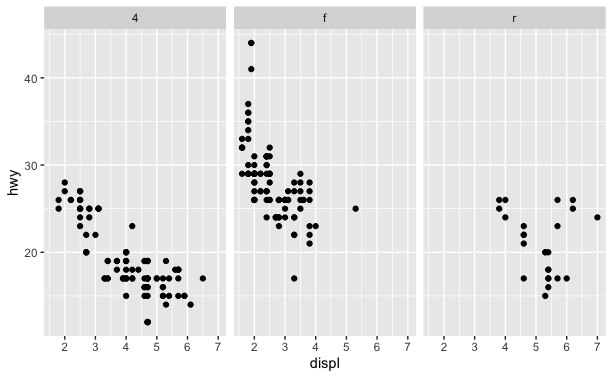

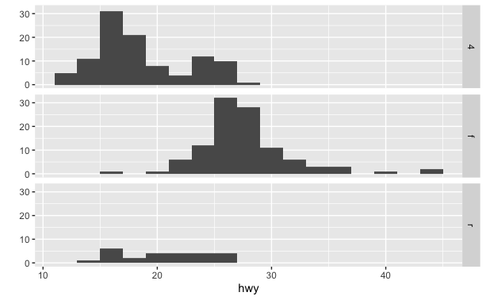